# Factor Analysis

Deviprasad Saka

2024-03-25

```r
# Factor Analysis

library(psych)

ship <- read.csv("D:/Multivariate Analysis/Assignment-6/Ship_data.csv")
```

```r
summary(ship)
```

```
##        Hs              P               Tp               V
##  Min.   :2.003   Min.   :14935   Min.   : 7.844   Min.   : 9.055
##  1st Qu.:2.816   1st Qu.:17593   1st Qu.:10.173   1st Qu.: 9.765
##  Median :3.673   Median :20091   Median :11.403   Median :10.172
##  Mean   :3.555   Mean   :19793   Mean   :11.197   Mean   :10.250
##  3rd Qu.:4.280   3rd Qu.:21925   3rd Qu.:12.238   3rd Qu.:10.857
##  Max.   :4.535   Max.   :22895   Max.   :13.072   Max.   :11.324
##       dist             hours             n               t
##  Min.   :  25.57   Min.   :2.006   Min.   :2.044   Min.   :0.1951
##  1st Qu.:1223.57   1st Qu.:2.104   1st Qu.:2.125   1st Qu.:0.1997
##  Median :2447.14   Median :2.294   Median :2.194   Median :0.2051
##  Mean   :2447.40   Mean   :2.256   Mean   :2.184   Mean   :0.2047
##  3rd Qu.:3670.71   3rd Qu.:2.390   3rd Qu.:2.242   3rd Qu.:0.2095
##  Max.   :4894.28   Max.   :2.498   Max.   :2.266   Max.   :0.2150
##      tot_r            w             wave_dir
##  Min.   :1015   Min.   :0.2056   Min.   : 25.03
##  1st Qu.:1159   1st Qu.:0.2237   1st Qu.:165.36
##  Median :1290   Median :0.2433   Median :171.62
##  Mean   :1273   Mean   :0.2417   Mean   :165.19
##  3rd Qu.:1383   3rd Qu.:0.2582   3rd Qu.:177.26
##  Max.   :1432   Max.   :0.2744   Max.   :179.83
```

Q: Decide how many Factors are ideal for your dataset? Ans: In my dataset, I selected four factors because I believe these factors adequately capture the underlying structure and variation present in the data. By choosing four factors, I aim to simplify the analysis while still retaining enough information to effectively understand the patterns and relationships within the dataset. These factors are chosen based on their ability to explain the most significant sources of variability in the data, making it easier to interpret and draw insights from the analysis.

```r
fit.pc <- principal(ship, nfactors=4, rotate="varimax")
fit.pc
```

```
## Principal Components Analysis
## Call: principal(r = ship, nfactors = 4, rotate = "varimax")
## Standardized loadings (pattern matrix) based upon correlation matrix
##            RC1   RC2   RC3   RC4   h2     u2 com
## Hs        0.99  0.01  0.02  0.01 0.98 0.0213 1.0
## P         1.00  0.05  0.00  0.00 0.99 0.0061 1.0
## Tp        0.07  0.99  0.02  0.03 0.98 0.0232 1.0
## V        -0.12  0.02  0.15  0.76 0.62 0.3782 1.1
## dist      0.14 -0.97 -0.01 -0.06 0.96 0.0390 1.1
## hours    -0.04  0.02  0.77 -0.06 0.61 0.3945 1.0
## n         1.00  0.06  0.00  0.00 1.00 0.0049 1.0
## t         0.05 -0.03  0.72  0.04 0.53 0.4741 1.0
## tot_r     1.00  0.05  0.00  0.00 0.99 0.0052 1.0
## w         0.13  0.06 -0.17  0.75 0.61 0.3913 1.2
## wave_dir  0.51  0.73 -0.07  0.03 0.79 0.2122 1.8
##
##                        RC1  RC2  RC3  RC4
## SS loadings           4.27 2.45 1.18 1.16
## Proportion Var        0.39 0.22 0.11 0.11
## Cumulative Var        0.39 0.61 0.72 0.82
## Proportion Explained  0.47 0.27 0.13 0.13
## Cumulative Proportion 0.47 0.74 0.87 1.00
##
## Mean item complexity =  1.1
## Test of the hypothesis that 4 components are sufficient.
##
## The root mean square of the residuals (RMSR) is  0.08
##  with the empirical chi square  71.66  with prob <  1.1e-08
##
## Fit based upon off diagonal values = 0.96
```

The provided outputrepresent the results of a factor analysis or a similar statistical analysis technique. Here’s a breakdown of the information:

RC1, RC2, RC3, RC4: These are the names of the factors extracted from the data. Each factor represents a linear combination of the original variables in the dataset.

- The subsequent rows represent the loadings of each variable on the factors. Loadings indicate the strength and direction of the relationship between variables and factors. For example:

Hs*: This variable has loadings of 0.99, 0.01, 0.02, and 0.01 on factors RC1, RC2, RC3, and RC4 respectively. P, Tp, V, dist, hours, n, t, tot_r, w: These variables similarly have loadings on each of the factors.

These results provide insights into how each variable contributes to the extracted factors and help in understanding the underlying structure of the data.

Q: How do eigenvalues and loadings show relationships between variables in factor analysis or PCA?

```r
round(fit.pc$values, 3)
```

```
##  [1] 4.391 2.352 1.185 1.122 0.891 0.757 0.286 0.012 0.005 0.000 0.000
```

```r
fit.pc$loadings
```

```
##
## Loadings:
##          RC1    RC2    RC3    RC4
## Hs        0.989
## P         0.996
## Tp               0.985
## V        -0.125         0.147  0.764
## dist      0.144 -0.968
## hours                   0.775
## n         0.995
## t                       0.721
## tot_r     0.996
## w         0.130        -0.167  0.748
## wave_dir  0.505  0.725
##
##                  RC1   RC2   RC3   RC4
## SS loadings    4.270 2.449 1.176 1.156
## Proportion Var 0.388 0.223 0.107 0.105
## Cumulative Var 0.388 0.611 0.718 0.823
```

Ans: The above results explains the eigenvalues of the principal components to three decimal places and displays the loadings matrix, showing the correlation between the original variables and the principal components in a factor analysis or principal component analysis (PCA).

Eigenvalues: The first line shows the rounded eigenvalues of the principal components. These values indicate the amount of variance explained by each principal component. The first four eigenvalues are 4.391, 2.352, 1.185, and 1.122, suggesting that the first four components explain the most variance in the data.

SS loadings, Proportion Var, Cumulative Var: These metrics summarize the variance explained by each principal component. “SS loadings” shows the sum of squares of the loadings for each component, while “Proportion Var” indicates the proportion of variance explained by each component relative to the total variance. “Cumulative Var” represents the cumulative proportion of variance explained as more components are added.

Q: What specific loadings are extracted for the first principal component, and what do communalities represent?

```r
# Loadings with more digits
for (i in c(1,3,2,4)) { print(fit.pc$loadings[[1,i]])}
```

```
## [1] 0.9889375
## [1] 0.01879914
## [1] 0.01436443
## [1] 0.01181024
```

```r
# Communalities
fit.pc$communality
```

```
##        Hs         P        Tp         V      dist     hours         n         t
## 0.9786966 0.9938848 0.9768381 0.6217909 0.9609710 0.6054579 0.9951045 0.5258853
##     tot_r         w  wave_dir
## 0.9947978 0.6086531 0.7878037
```

```r
# Display the first 10 rows of the rotated factor scores with column ordering: RC1, RC3, RC2, and RC4
head(fit.pc$scores, 10)
```

```
##             RC1      RC2         RC3        RC4
##  [1,] -1.579614 1.476195  0.16627581 -0.5682811
##  [2,] -1.450935 1.480704  1.05732471 -0.1287935
##  [3,] -1.456592 1.371530  1.15376342  1.8717110
##  [4,] -1.460310 1.406410  1.47349397  0.9103725
##  [5,] -1.360564 1.488879 -0.61942355 -1.6340955
##  [6,] -1.370709 1.429730  0.85992176  1.4213189
##  [7,] -1.348954 1.382287 -1.70258585  0.7448130
##  [8,] -1.337536 1.424938 -1.22749581 -1.7298932
##  [9,] -1.309828 1.377276  0.05620004 -0.8412787
## [10,] -1.224718 1.295690 -0.61188032 -1.3849643
```

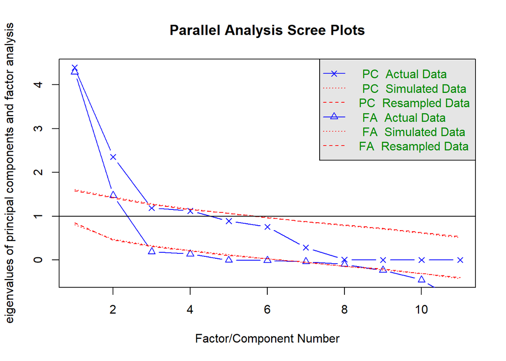

```
## Parallel analysis suggests that the number of factors =  2  and the number of components =  2
```

```r
fa.parallel(ship) # See factor recommendation
```

The scree plot helps to visualize the “elbow” or the point after which the addition of another component or factor does not significantly increase the explained variance. This is often used as a criterion for selecting the number of components or factors to retain in the analysis.

The scree plot in this image is enhanced by comparing actual data eigenvalues against those obtained through simulation and resampling techniques. This comparison is used to support the decision of how many components or factors to retain:

Actual Data: These lines represent the eigenvalues derived from the actual dataset being analyzed.

Simulated Data: These lines show eigenvalues from datasets that have been generated under some null hypothesis, usually assuming that the data have no underlying factor structure.

Resampled Data: This refers to eigenvalues obtained from a method like bootstrapping or permutation, where the original data is resampled with replacement to create new samples, and the analysis is repeated to assess the stability of the eigenvalues.

The x-axis of the plot represents the factor or component number, while the y-axis represents the magnitude of the eigenvalues. Typically, the point where the line starts to flatten out (the elbow) suggests the number of factors or components that should be retained. This is where the actual data eigenvalues fall below the eigenvalues of the simulated or resampled data, indicating that additional factors or components are likely not meaningful and are simply explaining noise.

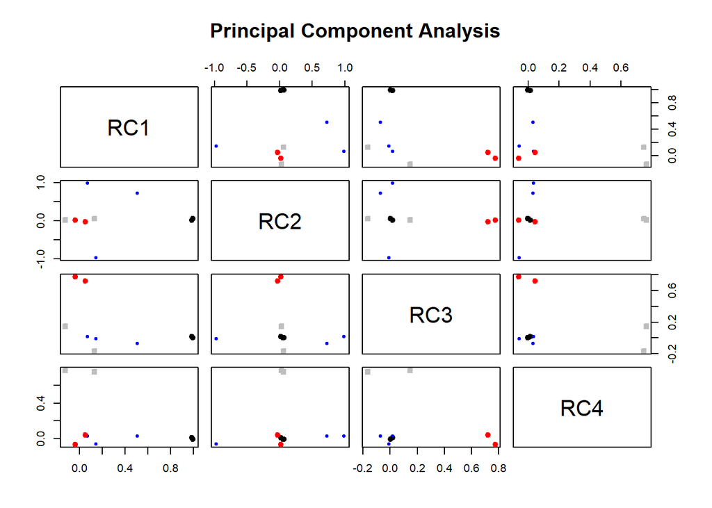

```r
fa.plot(fit.pc) # See Correlations within Factors
```

Q: Explain the output for your factor model and Show the columns that go into each factor?

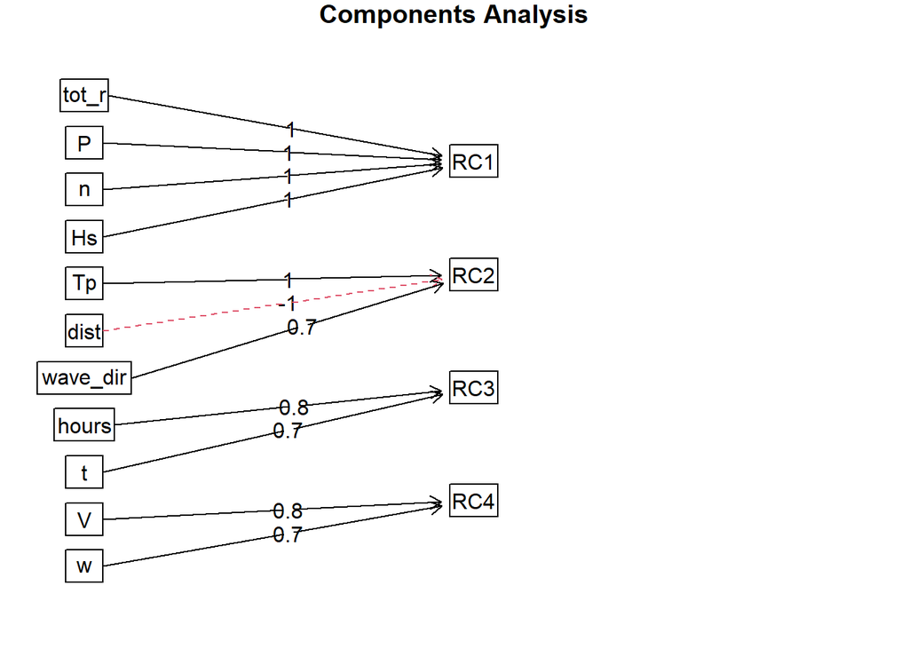

```r
fa.diagram(fit.pc) # Visualize the relationship
```

The component loadings shown in the diagram represent the strength and direction of the relationship between the original variables and the principal components (RC1, RC2, RC3, and RC4). Here’s an interpretation of the diagram:

In summary, the component loadings help in understanding which variables are most influential in defining each principal component and can provide insight into the underlying structure of the data. This information is valuable for reducing dimensionality while retaining the essence of the original data, which can be useful in subsequent analysis, visualization, or modeling.

1. By combining the variables Significant wave height, engine power, propeller RPM, and total resistance faced by the ship, we can potentially derive a single factor related to the ship’s Relative rotative efficiency.

ii)By combining the variables peak wave period, distance traveled along the route, and wave direction faced by the ship, we may extract a single factor related to the ship’s navigational conditions or its response to wave dynamics. This factor could potentially represent the ship’s open water efficiency.

3. Combining the variables Time spent from current point on the route to the next one and Thrust deduction fraction of ship could potentially yield a factor related to Hull efficiency.

iv)Combining ship speed and wake fraction variables could potentially yield a factor related to the ship Quasi propulsive efficiency.

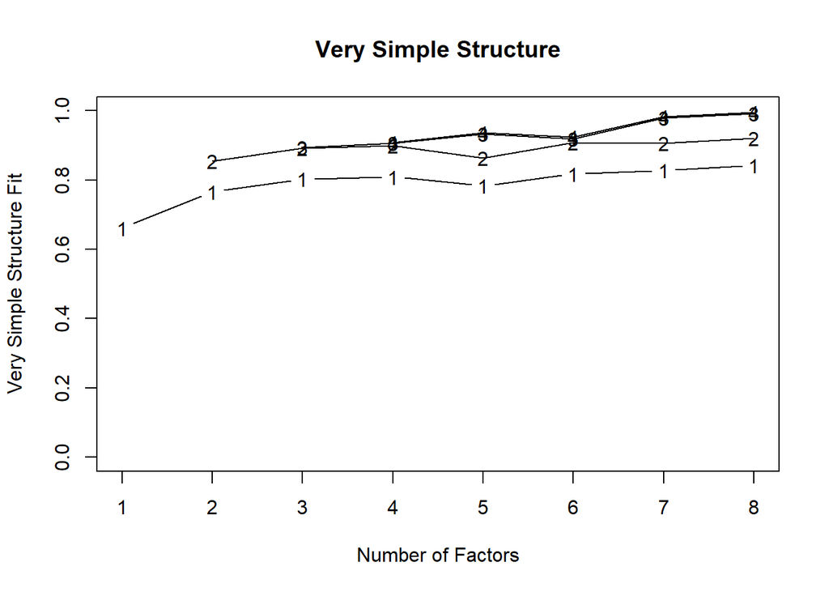

```
##
## Very Simple Structure
## Call: vss(x = ship)
## Although the VSS complexity 1 shows  8  factors, it is probably more reasonable to think about  4  factors
## VSS complexity 2 achieves a maximimum of 0.92  with  8  factors
##
## The Velicer MAP achieves a minimum of 0.21  with  2  factors
## BIC achieves a minimum of  803.77  with  5  factors
## Sample Size adjusted BIC achieves a minimum of  835.35  with  5  factors
##
## Statistics by number of factors
##   vss1 vss2  map dof   chisq     prob sqresid  fit  RMSEA     BIC   SABIC
## 1 0.66 0.00 0.29  44 1.7e+03 9.9e-324    9.79 0.66   0.61 1.5e+03 1.6e+03
## 2 0.77 0.85 0.21  34 2.2e+08  0.0e+00    4.19 0.85 253.91 2.2e+08 2.2e+08
## 3 0.80 0.89 0.22  25 2.2e+08  0.0e+00    3.06 0.89 296.04 2.2e+08 2.2e+08
## 4 0.81 0.90 0.28  17 2.1e+08  0.0e+00    2.65 0.91 355.09 2.1e+08 2.1e+08
## 5 0.78 0.86 0.36  10 8.5e+02 4.2e-176    1.82 0.94   0.92 8.0e+02 8.4e+02
## 6 0.82 0.91 0.72   4 8.9e+02 2.2e-191    2.17 0.92   1.50 8.7e+02 8.8e+02
## 7 0.83 0.91 0.50  -1 8.2e+02       NA    0.46 0.98     NA      NA      NA
## 8 0.84 0.92 0.65  -5 8.2e+02       NA    0.12 1.00     NA      NA      NA
##   complex  eChisq    SRMR  eCRMS eBIC
## 1     1.0 3.4e+02 0.17683 0.1977  138
## 2     1.3 1.3e+01 0.03511 0.0447 -143
## 3     1.3 6.3e+00 0.02403 0.0356 -109
## 4     1.1 1.0e+00 0.00980 0.0176  -77
## 5     1.4 9.9e-02 0.00302 0.0071  -46
## 6     1.3 1.6e-02 0.00121 0.0045  -18
## 7     1.2 1.5e-03 0.00038     NA   NA
## 8     1.2 1.5e-03 0.00037     NA   NA
```

```r
vss(ship) # See Factor recommendations for a simple structure
```

```r
# Computing Correlation Matrix
corrm.emp <- cor(ship)
corrm.emp
```

```
##                   Hs           P           Tp            V         dist
## Hs        1.00000000  0.99025464  0.096931757 -0.075195890  0.108328779
## P         0.99025464  1.00000000  0.127059337 -0.102038814  0.082647727
## Tp        0.09693176  0.12705934  1.000000000  0.044215802 -0.971128274
## V        -0.07519589 -0.10203881  0.044215802  1.000000000 -0.092237354
## dist      0.10832878  0.08264773 -0.971128274 -0.092237354  1.000000000
## hours    -0.02769336 -0.03121453  0.010445485  0.048202287 -0.005938276
## n         0.98908225  0.99940765  0.138121110 -0.101040933  0.072103356
## t         0.04911540  0.03447904 -0.002924541 -0.007536943  0.013831018
## tot_r     0.98991676  0.99988140  0.128818613 -0.101825092  0.081210177
## w         0.09878712  0.10648417  0.088143401  0.152182107 -0.071712499
## wave_dir  0.46545650  0.51336966  0.683238515 -0.032501505 -0.542904297
##                 hours           n             t       tot_r             w
## Hs       -0.027693355  0.98908225  0.0491153969  0.98991676  0.0987871222
## P        -0.031214534  0.99940765  0.0344790383  0.99988140  0.1064841658
## Tp        0.010445485  0.13812111 -0.0029245414  0.12881861  0.0881434012
## V         0.048202287 -0.10104093 -0.0075369433 -0.10182509  0.1521821067
## dist     -0.005938276  0.07210336  0.0138310177  0.08121018 -0.0717124993
## hours     1.000000000 -0.02772242  0.1566456101 -0.02956434 -0.0965853934
## n        -0.027722418  1.00000000  0.0331672173  0.99980618  0.1119050201
## t         0.156645610  0.03316722  1.0000000000  0.03395737 -0.0005821467
## tot_r    -0.029564338  0.99980618  0.0339573703  1.00000000  0.1087631954
## w        -0.096585393  0.11190502 -0.0005821467  0.10876320  1.0000000000
## wave_dir -0.042836718  0.52779161 -0.0432163409  0.51834267  0.1467017698
##             wave_dir
## Hs        0.46545650
## P         0.51336966
## Tp        0.68323851
## V        -0.03250150
## dist     -0.54290430
## hours    -0.04283672
## n         0.52779161
## t        -0.04321634
## tot_r     0.51834267
## w         0.14670177
## wave_dir  1.00000000
```

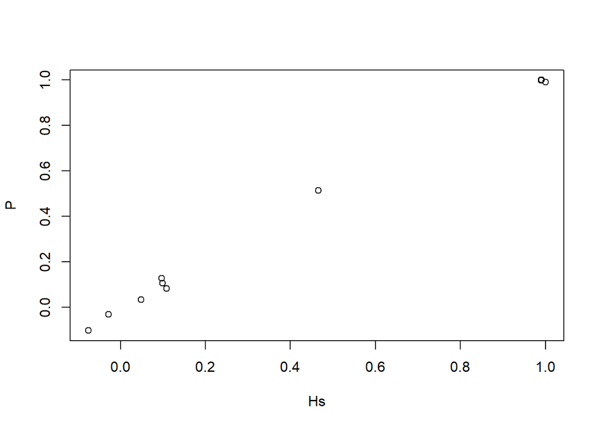

```r
plot(corrm.emp)
```

```r
ship_pca <- prcomp(ship, scale=TRUE)
summary(ship_pca)
```

```
## Importance of components:
##                           PC1    PC2    PC3    PC4     PC5     PC6     PC7
## Standard deviation     2.0954 1.5338 1.0886 1.0591 0.94384 0.86990 0.53465
## Proportion of Variance 0.3992 0.2139 0.1077 0.1020 0.08098 0.06879 0.02599
## Cumulative Proportion  0.3992 0.6130 0.7207 0.8227 0.90370 0.97249 0.99848
##                            PC8     PC9    PC10      PC11
## Standard deviation     0.10772 0.06839 0.02073 0.0003534
## Proportion of Variance 0.00105 0.00043 0.00004 0.0000000
## Cumulative Proportion  0.99954 0.99996 1.00000 1.0000000
```

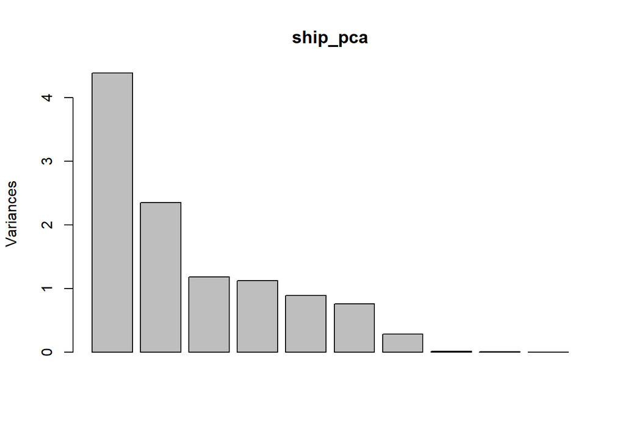

```r
plot(ship_pca)
```

```r
# A table containing eigenvalues and %'s accounted, follows. Eigenvalues are the sdev^2
(eigen_ship <- round(ship_pca$sdev^2,3))
```

```
##  [1] 4.391 2.352 1.185 1.122 0.891 0.757 0.286 0.012 0.005 0.000 0.000
```

```r
round(fit.pc$values, 3)
```

```
##  [1] 4.391 2.352 1.185 1.122 0.891 0.757 0.286 0.012 0.005 0.000 0.000
```

```r
names(eigen_ship) <- paste("PC",1:9,sep="")
eigen_ship
```

```
##   PC1   PC2   PC3   PC4   PC5   PC6   PC7   PC8   PC9  <NA>  <NA>
## 4.391 2.352 1.185 1.122 0.891 0.757 0.286 0.012 0.005 0.000 0.000
```

```r
sumlambdas <- sum(eigen_ship)
sumlambdas
```

```
## [1] 11.001
```

```r
propvar <- round(eigen_ship/sumlambdas,2)
propvar
```

```
##  PC1  PC2  PC3  PC4  PC5  PC6  PC7  PC8  PC9 <NA> <NA>
## 0.40 0.21 0.11 0.10 0.08 0.07 0.03 0.00 0.00 0.00 0.00
```

```r
cumvar_ship <- cumsum(propvar)
cumvar_ship
```

```
##  PC1  PC2  PC3  PC4  PC5  PC6  PC7  PC8  PC9 <NA> <NA>
## 0.40 0.61 0.72 0.82 0.90 0.97 1.00 1.00 1.00 1.00 1.00
```

```r
matlambdas <- rbind(eigen_ship,propvar,cumvar_ship)
matlambdas
```

```
##               PC1   PC2   PC3   PC4   PC5   PC6   PC7   PC8   PC9 <NA> <NA>
## eigen_ship  4.391 2.352 1.185 1.122 0.891 0.757 0.286 0.012 0.005    0    0
## propvar     0.400 0.210 0.110 0.100 0.080 0.070 0.030 0.000 0.000    0    0
## cumvar_ship 0.400 0.610 0.720 0.820 0.900 0.970 1.000 1.000 1.000    1    1
```

```r
rownames(matlambdas) <- c("Eigenvalues","Prop. variance","Cum. prop. variance")
rownames(matlambdas)
```

```
## [1] "Eigenvalues"         "Prop. variance"      "Cum. prop. variance"
```

```r
eigvec.emp <- ship_pca$rotation
print(ship_pca)
```

```
## Standard deviations (1, .., p=11):
##  [1] 2.0954014174 1.5337584338 1.0885979855 1.0591109856 0.9438380643
##  [6] 0.8699025621 0.5346458455 0.1077155890 0.0683873173 0.0207310312
## [11] 0.0003534273
##
## Rotation (n x k) = (11 x 11):
##                  PC1           PC2          PC3          PC4         PC5
## Hs        0.45939093 -1.467727e-01  0.015256464 -0.031732115 -0.04497556
## P         0.46671265 -1.259564e-01  0.009613456 -0.007747319 -0.03699363
## Tp        0.14599011  6.086830e-01  0.075109490  0.066864799  0.01379362
## V        -0.04907366  9.961068e-02 -0.159777949 -0.705064367 -0.45925260
## dist     -0.04578389 -6.336746e-01 -0.060308099 -0.050496263 -0.01340977
## hours    -0.02158024 -3.762628e-05  0.672196137 -0.246129217 -0.44139493
## n         0.46816656 -1.175992e-01  0.009934164 -0.009434857 -0.03750737
## t         0.01538457 -3.501686e-02  0.584553405 -0.323001175  0.65886674
## tot_r     0.46718094 -1.242143e-01  0.009579721 -0.008760043 -0.03728163
## w         0.07543442  8.514482e-02 -0.413314311 -0.569787918  0.39188306
## wave_dir  0.31857663  3.780177e-01 -0.017257407  0.071155740 -0.00465957
##                  PC6         PC7          PC8          PC9          PC10
## Hs       -0.05399504  0.17572156 -0.854178695 -0.026678811  0.0051895453
## P        -0.02663660  0.10501678  0.293904047 -0.013711623 -0.6882036574
## Tp       -0.02559351  0.26472698  0.005561203  0.725861992  0.0156792456
## V        -0.50045623 -0.05240747  0.024310686  0.017823698  0.0003258806
## dist      0.04167349 -0.35182547 -0.010448481  0.681311805  0.0132985293
## hours     0.54031379 -0.01476260 -0.004122516 -0.009582530 -0.0034387105
## n        -0.02021969  0.08499482  0.298444208 -0.043998230  0.7241423894
## t        -0.33734792 -0.06693276  0.009738808 -0.004550404  0.0003707999
## tot_r    -0.02350153  0.09377004  0.297744377 -0.027185824 -0.0355722587
## w         0.57915542  0.05005133 -0.007350330  0.003521916 -0.0028492695
## wave_dir  0.03744492 -0.85922368 -0.073358947 -0.070151934 -0.0160727228
##                   PC11
## Hs       -1.335650e-03
## P         4.391622e-01
## Tp       -1.219073e-03
## V         7.060179e-05
## dist      1.975304e-03
## hours     5.783606e-05
## n         3.773275e-01
## t         7.949286e-05
## tot_r    -8.153239e-01
## w        -1.646209e-05
## wave_dir  5.519465e-04
```

```r
# Taking the first four PCs to generate linear combinations for all the variables with four factors
pcafactors.emp <- eigvec.emp[,1:4]
pcafactors.emp
```

```
##                  PC1           PC2          PC3          PC4
## Hs        0.45939093 -1.467727e-01  0.015256464 -0.031732115
## P         0.46671265 -1.259564e-01  0.009613456 -0.007747319
## Tp        0.14599011  6.086830e-01  0.075109490  0.066864799
## V        -0.04907366  9.961068e-02 -0.159777949 -0.705064367
## dist     -0.04578389 -6.336746e-01 -0.060308099 -0.050496263
## hours    -0.02158024 -3.762628e-05  0.672196137 -0.246129217
## n         0.46816656 -1.175992e-01  0.009934164 -0.009434857
## t         0.01538457 -3.501686e-02  0.584553405 -0.323001175
## tot_r     0.46718094 -1.242143e-01  0.009579721 -0.008760043
## w         0.07543442  8.514482e-02 -0.413314311 -0.569787918
## wave_dir  0.31857663  3.780177e-01 -0.017257407  0.071155740
```

```r
# Multiplying each column of the eigenvector’s matrix by the square-root of the corresponding eigenvalue in order to get the factor loadings
unrot.fact.emp <- sweep(pcafactors.emp,MARGIN=2,ship_pca$sdev[1:4],`*`)
unrot.fact.emp
```

```
##                  PC1           PC2         PC3          PC4
## Hs        0.96260842 -2.251139e-01  0.01660816 -0.033607831
## P         0.97795034 -1.931867e-01  0.01046519 -0.008205270
## Tp        0.30590789  9.335727e-01  0.08176404  0.070817243
## V        -0.10282902  1.527787e-01 -0.17393395 -0.746741417
## dist     -0.09593563 -9.719038e-01 -0.06565127 -0.053481146
## hours    -0.04521926 -5.770962e-05  0.73175136 -0.260678158
## n         0.98099687 -1.803687e-01  0.01081431 -0.009992561
## t         0.03223686 -5.370741e-02  0.63634366 -0.342094093
## tot_r     0.97893161 -1.905147e-01  0.01042846 -0.009277858
## w         0.15806540  1.305916e-01 -0.44993313 -0.603468644
## wave_dir  0.66754592  5.797878e-01 -0.01878638  0.075361825
```

```r
# Computing communalities
communalities.emp <- rowSums(unrot.fact.emp^2)
communalities.emp
```

```
##        Hs         P        Tp         V      dist     hours         n         t
## 0.9786966 0.9938848 0.9768381 0.6217909 0.9609710 0.6054579 0.9951045 0.5258853
##     tot_r         w  wave_dir
## 0.9947978 0.6086531 0.7878037
```

```r
# Performing the varimax rotation. The default in the varimax function is norm=TRUE thus, Kaiser normalization is carried out
rot.fact.emp <- varimax(unrot.fact.emp)
#View(unrot.fact.emp)
rot.fact.emp
```

```
## $loadings
##
## Loadings:
##          PC1    PC2    PC3    PC4
## Hs        0.989
## P         0.996
## Tp               0.985
## V        -0.125         0.147 -0.764
## dist      0.144 -0.968
## hours                   0.775
## n         0.995
## t                       0.721
## tot_r     0.996
## w         0.130        -0.167 -0.748
## wave_dir  0.505  0.725
##
##                  PC1   PC2   PC3   PC4
## SS loadings    4.270 2.449 1.176 1.156
## Proportion Var 0.388 0.223 0.107 0.105
## Cumulative Var 0.388 0.611 0.718 0.823
##
## $rotmat
##              [,1]       [,2]        [,3]        [,4]
## [1,]  0.969948000 0.24198138 -0.01662212 -0.01922476
## [2,] -0.242699489 0.96033645 -0.02587584 -0.13483808
## [3,]  0.003127056 0.08219436  0.91059813  0.40502513
## [4,] -0.016972221 0.11154822 -0.41214705  0.90410384
```

```r
# The print method of varimax omits loadings less than abs(0.1). In order to display all the loadings, it is necessary to ask explicitly the contents of the object $loadings
fact.load.emp <- rot.fact.emp$loadings[1:9,1:4]
fact.load.emp
```

```
##               PC1         PC2          PC3           PC4
## Hs     0.98893747  0.01436443  0.018799140 -0.0118102394
## P      0.99561928  0.05106644  0.001654617  0.0040683096
## Tp     0.06919089  0.98518798  0.016025244 -0.0346195212
## V     -0.12468816  0.02424220  0.147139298 -0.7642029269
## dist   0.14353039 -0.96793118 -0.010996348  0.0579510548
## hours -0.03713381  0.02007001  0.774522288  0.0615746773
## n      0.99549476  0.06394255  0.002326837  0.0008068949
## t      0.05209882 -0.02963259  0.721300297 -0.0449313518
## tot_r  0.99594066  0.05374721  0.001977789  0.0027045586
```

```r
# Computing the rotated factor scores, Notice that signs are reversed for factors F2 (PC2), F3 (PC3) and F4 (PC4)
scale.emp <- scale(ship)
scale.emp
```

[output not shown]

[output cut: 295 more lines]